# Définition de la série de Fourier

La série de [Fourier](https://fr.wikipedia.org/wiki/S%C3%A9rie_de_Fourier#:~:text=En%20analyse%20math%C3%A9matique%2C%20les%20s%C3%A9ries,Fourier%20pour%20un%20signal%20carr%C3%A9.) est une méthode d'analyse des signaux périodiques, cette méthode se construit sur deux concepts majeurs :

- **L'analyse** : le fait de déterminer les coefficients représentatifs de la fonction sur la série de Fourier.
- **La synthèse** : le fait de retrouver la fonction à partir de ses coefficients.

Précisons les choses avec un exemple : construisons la représentation de la fonction $ \cos(x) $.

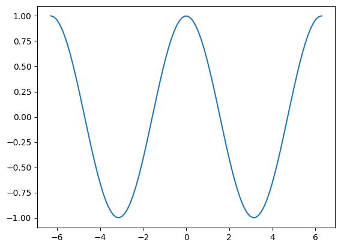

```python
import numpy as np
import matplotlib.pyplot as plt

def fonction(x):
    return np.cos(x)

# Définition du nombre de points et de l'espacement de la courbe
x = np.linspace(-2 * np.pi, 2 * np.pi, 100)

# Calculer les valeurs de cos(x)
y = fonction(x)

# Tracer la courbe
plt.plot(x, y)
plt.show()
```

Maintenant que nous avons une fonction périodique, la série de Fourier va la représenter par des sommes infinies.

La série de Fourier s'exprime de [la manière suivante](https://questions-responses.com/mathematiques-et-sciences/quest-ce-quune-serie-de-fourier/) :

$$ f(x) = \frac{a_0}{2} + \sum_{n=1}^\infty \left[ a_n \cos(nx) + b_n \sin(nx) \right] $$

### Les paramètres

$$ a_0 $$

Dans cette formule, $ a_0 $ représente le terme moyen, le coefficient constant de la série de Fourier relative à la fonction que l'on analyse, dans notre cas $ \cos(x) $.

On a alors $ a_0 $ qui s'exprime de la manière suivante :

$$ a_0 = \frac{1}{T} \int_{0}^{T} f(x) \, dx $$

où $ T $ est la période de la fonction $ f(x) $, qui vaut :

$$ f(x + T) = f(x) \quad \text{pour tout } x $$

On les définit en Python de la manière suivante :

```python
from scipy.integrate import quad

# On définit le calcul de la période T avec un step pour la précision et un epsilon pour le taux d'imprécision

def delta_T(f, x, step=0.01, epsilon=0.001, TMAX=1000, TMIN=0.5):

    # On initialise T
    t = TMIN

    # On vérifie si elles sont égales
    while abs(f(x + t) - f(x)) > epsilon:
        t += step

    return t

# Définition du calcul a0

def a0(f):

    # On récupère T
    T = delta_T(f, 0)

    # On calcule l'intégrale sans dx qui n'est pas nécessaire pour la méthode quad, il est géré en interne
    integral, _ = quad(f, 0, T)

    # On retourne le résultat du calcul de a0
    return (1/T) * integral
```

$$ a_n $$

Dans cette formule, $ a_n $ représente le coefficient associé à cosinus que l'on détermine de la manière suivante :

$$ g(x) = f(x) \cdot \cos\left(\frac{2\pi nx}{T}\right) $$

Dans la formule de la série de Fourier, $ n $ est appelé coefficient d'harmonie. Il est au début choisi de manière arbitraire et ensuite réajusté pour correspondre à $ f(x) $ par tâtonnement. Elle introduit aussi l'idée de troncature d'ordre $ n $ dans la série de Fourier : on se limite aux valeurs les plus significatives au cours de l'approximation de la fonction.

comme a0 on définit $an$ en python :

```python
# Définition du calcul a_n
def an(f, n):

    # On récupère T comme pour a0
    T = delta_T(f,0)

    # Définition de la fonction g(x) comme produit entre f(x) et cosinus
    def g(x):
        return f(x) * np.cos(2 * np.pi * n * x / T)

     # On calcule l'intégrale sans dx qui n'est pas nécessaire pour la méthode quad,il est géré en interne
    integral, _ = quad(g, 0, T)

    # On retourne le résultat du calcul de a_n
    return (2 / T) * integral
```

$$ b_n $$

En code cela donne :

```python
# Définition du calcul b_n

def bn(f, n):

    # On récupère T comme pour a0
    T = delta_T(f, 0)

    # Définition de la fonction g(x) comme produit entre f(x) et sinus

    def g(x):
        return f(x) * np.sin(2 * np.pi * n * x / T)

    # On calcule l'intégrale sans dx, qui n'est pas nécessaire pour la méthode quad, il est géré en interne
    integral, _ = quad(g, 0, T)

    # On retourne le résultat du calcul de b_n
    return (2 / T) * integral
```

## Application de la série de Fourier

Nous avons défini ce qu'était la série de Fourier avec des fonctions sur chacun de ses paramètres. Maintenant, définissons la fonction d'approximation de la série de Fourier :

```python
# Définition de la série de Fourier

def fourier(f, x, n_terms):

    # On récupère la période
    T = delta_T(f, 0)

    # On calcule comme première valeur de retour a0
    somme = a0(f) / 2

    # On fait la somme relative à n de la série de Fourier
    for n in range(1, n_terms + 1):

        somme += an(f, n) * np.cos(2 * np.pi * n * x / T) + bn(f, n) * np.sin(2 * np.pi * n * x / T)

    # On retourne la somme finale
    return somme
```

Maintenant regardont son approximation en sur la fonction cosinus

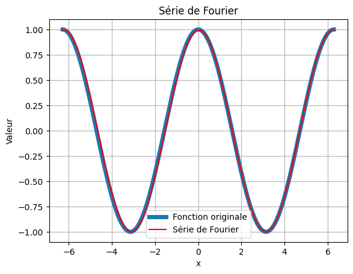

```python
# Fonction cible

import numpy as np
import matplotlib.pyplot as plt

# Définir l'intervalle
intervalle = np.linspace(-2 * np.pi, 2 * np.pi, 500)

# Calculer la série de Fourier
n_terms = 1

# Affichage du graphique

plt.plot(intervalle, [fonction(x) for x in intervalle], label="Fonction originale", linewidth=5)

plt.plot(intervalle, [fourier(fonction, x, n_terms) for x in intervalle], label="Série de Fourier", color='red')

plt.legend()
plt.xlabel("x")
plt.ylabel("Valeur")
plt.title("Série de Fourier")
plt.grid(True)
plt.show()
```